# class notes

Gwen

2024-01-25

```r
# first chunk of code in rmd file
print(pi)
```

```
## [1] 3.141593
```

```r
pi + 3
```

```
## [1] 6.141593
```

- `.Rmd` is Rstudio’s special blend of Markdown (a text rendering language)
- `.md` is the more generic Markdown file type. In Rstudio, the intermediae .md fileas are not (in the default state) preserved

## Languages

- `LaTex` Typesetting language invented in the 1970s by computer programmer Donald Knuth for proper rendering of text and equations. Hundres of commands. Precise, but somewhat complicated to use.
- `Markdown` Greatly simplified version of LaTex with a small number of commands to master. Easy to use, texts look great.
- `yaml`<sup>2</sup> Header material for `.Rmd` files that can be changed manually or by selecting options
- `R` Computer language for manipulating numbers, text, graphics, statistics

## Basic text formatting

- headers `#` to `######` *numbering from options
- text
- markup
  - *italic* `*text*`
  - **bold** `**text**`
  - sub<sub>script</sub> `~text~`
  - super<sup>script</sup> `^text^`
  - strikethrough `~~text~~`
  - “quotations”

## Spacing, manual breaks, lines

- line spacing effects
- two extra spaces at the end of a line for a manual break
- lists
  - indented
  - numbered

## Links

- links linking text
- footnotes<sup>2</sup>
- images

## subscripts in LaTex

$$H_0 = Z_{a + b}$$

## superscripts in LaTex

$$S = cA^z$$

$$S=cA^z_1 + Z_{2 + x}$$
special characters proceeded with backslash

$$\alpha = \frac{\beta}{\delta +
\gamma_x}$$

$$z = \sum_{i=1}^X{k}$$

what if you need to include a backslash in the equation? There’s a code for that

$$\backslash \alpha \le b
\backslash$$

## Rendering in plain text

$$P(Occurrence of Species A) = Z$$
$$P(\mbox{Occurrence of Species A}) =
Z$$

easy to embed LaTex in line $\pi + 3$ like so we can also use markdown fencing in line with a single backtick `pi + 3` like this. We can even execute r code inside of markdown text 6.1415927 << ” r pi + 3 ”

## R code in chunks

```r
# use comments extensively in all of your coding!
Pred <- seq(1,10) # make a vector of integers from 1 to 10
Res <- runif(10) # generate 10 draws from a random uniform (0,1) distribution

# print the random numbers
print(Res)
```

```
##  [1] 0.9381878 0.5548224 0.8102722 0.1115971 0.9077769 0.7503939 0.3060632
##  [8] 0.7273445 0.8039238 0.2936543
```

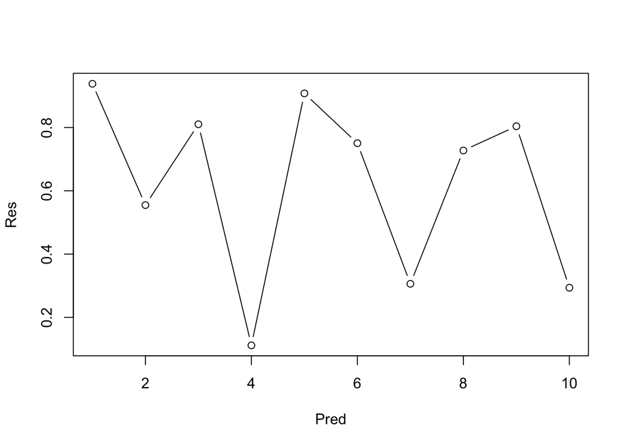

```r
# plot the graph
plot(x=Pred,y=Res,type="b")
```